# Session Regularization

### Learning outcomes

- Likelihood
  - Relation to OLS for linear model
  - Likelihood and an orientation to Bayesian statistics
- Overfitting
- Regularization
  - relation to Bayesian statistics
  - Model comparison
    - AIC
  - Feature selection
    - LASSO, ridge regression
- Cross validation

# Likelihood

**Lecture notes**

Likelihood is concerned with estimating how likely it is that a certain model or certain model parameter values are *true* ones.

Consider a generative model, with parameters $\theta$, for how $X\rightarrow Y$. We would like to test if $\theta$ are good parameters. Given the model, we can compute $Pr[Y| X, \theta]$, that is, the probability that the model with parameters $\theta$ and given $X$ generates $Y$.

Likelihood builds on the intuition that if $\theta$ (or the model) is close to the ‘truth’, then $Pr[Y| X, \theta]$ will be higher than for wrong $\theta$ (model). We should therefore select the $\theta$ that maximizes $Pr[Y| X, \theta]$; this is called maximum likelihood estimation (MLE) of $\theta$.

Since statistical model contain an element of randomness, the reasoning above might not always be correct for any single obeservation. However, if we sum over a large number of observations it will be true on average. Hence the need for datasets that are large enough.

To formalize this intuition, Edwards (1972) defined the likelihood of model parameters being true given observed data as

$$L[\theta|Y,X] \propto Pr[Y|X, \theta]$$

**Extra Reading**

Notice that this notation is not uncommonly mixed up, so you might also see the notation $L[Y|X,\theta]$ for the likelihood.

Similarly $Pr[Y|X, \theta]$ is often referred to as the *likelihood function* or simply the likelihood.

Notice that this means that $L[\theta|Y,X]$ is not a proper probability, hence the term *likelihood* is used.

**Extra Reading**

In fact, for continuous $Y$, $Pr[Y|X, \theta]$ may be a density $f[Y|X, \theta]$ rather than a probability.

In practice, the proportionality is ignored and we set

$$L[\theta|Y,X] = Pr[Y|X, \theta]$$

**Extra Reading**

The proportionality (indicated by ‘$\propto$’) means there are some unknown constant factor, $k$, such that $L[\theta|Y,X] = k Pr[Y|X, \theta]$. However, the factor $k$ is assumed to be constant over $\theta$s and over models.

When the likelihood of two $\theta$s (or models) are compared this is almost always done as a *likelihood ratio*,

$$\frac{L[\theta_1|Y,X]}{L[\theta_0|Y,X]} = \frac{k Pr[Y|X, \theta_1]}{ k Pr[Y|X, \theta_0]} =\frac{Pr[Y|X, \theta_1]}{ Pr[Y|X, \theta_0]}$$

which means that the factor $k$ disappears. Hence the factor $k$ is always ignored. Likelihood ratios is the basis of most model comparison statistics, e.g., the Wald test, the Score test, regularization…

In maximum likelihood estimation, *MLE*, of some parameters $\theta$, one simply selects the estimates $\widehat\theta$ that gives the highest likelihood, i.e.,
$$\widehat{\theta} = max_{\theta}L[\theta|X,Y] = L[\widehat\theta|X,Y].$$
In many applications of likelihood and maximum likelihood, it is practical to instead use the logarithm of the likelihood, the logLikelihood,
$$\log L[\theta_1|Y,X].$$

**Extra Reading**

Likelihood and maximum likelihood estimation are central concepts in statistics. Many statistical tests and methods uses or is based on the concept of maximum likelihood.

(In the following, I will simplify notation and not differentiate between etimates and random variables, e.g., $\theta$ will be used also for $\widehat\theta$.)

## Likelihood | `Likelihood and OLS for linear models`

**Lecture notes**

So, why have we used ordinary least squares (OLS), i.e., minimization of RSS when estimating linear model parameters $\beta$ rather than maximum likelihood estimation?

Linear models is a special case with some nice properties when it comes to likelihood. Consider a simple linear regression model,

$$y = \beta x + \epsilon,$$

where the residuals $\epsilon\sim N(0,\sigma^2)$.

It turns out that the maximum likelihood estimates of both $\beta$ and $\sigma^2$ are functions of the RSS of the residuals, so that the likelihood can be approximated by

$$\log L[\beta, \sigma^2|Y,X] \approx -\frac{N}{2} \log RSS$$

**Extra Reading**

The likelihood for given $\beta$ and $\sigma^2$, given observed data $Y$ and $X$ is given by

$$L[\beta, \sigma^2|Y,X] = \prod_i pdf_{Normal}(y_i, \mu=\beta x_i, \sigma^2=\sigma^2) = \prod_i \frac{1}{\sqrt{2\pi \sigma^2}}e^{-\frac{(y_i-\beta x_i)^2}{2\sigma^"}}$$

where $pdf_{Normal}$ denotes the probability distribution function for the Normal distribution. If we work with the logLikelihood instead, we get

$$\begin{eqnarray*}
\log L[\beta, \sigma^2|Y,X]
&=& \sum_{i=1}^N \log\left(\frac{1}{\sqrt{2\pi \sigma^2}}e^{-\frac{(y_i-\beta x_i)^2}{2\sigma^2}}\right)\\
&=& \sum_{i=1}^N \log \left(\frac{1}{\sqrt{2\pi \sigma^2}}\right) -\frac{(y_i-\beta x_i)^2}{2\sigma^2} \\
&=& N\log \left(2\pi \sigma^2\right)^{-1/2} -\frac{\sum_{i=1}^N (y_i-\beta x_i)^2}{2\sigma^2} \\
&=& -\frac{N}{2}\log \left(2\pi \sigma^2\right) -\frac{RSS}{2\sigma^2}
\end{eqnarray*}$$

We see here that minimizing $RSS$ (as in OLS) will maximize the logLikelihood, regardless of the value of $\sigma^2$. Moreover, it turns out that also $\sigma^2$ can be estimated fairly well by $RSS/N$. Hence, we get

$$\begin{eqnarray*}
\log L[\beta, \sigma^2|Y,X]
&=& -\frac{N}{2}\log \left(\frac{2\pi RSS}{N}\right) -\frac{N}{2}\frac{RSS}{RSS}\\
&=& -\frac{N}{2}\log RSS + \frac{N}{2}\log \frac{2\pi}{N} -\frac{N}{2}\\
&=& -\frac{N}{2}\log RSS + C
\end{eqnarray*}$$
where $C=\frac{N}{2}\left(\log \frac{2\pi}{N} -1\right)$ is a constant that is usually ignored (in likelihood ratios, which is equivalent to log likelihoods differences, it will disappear).

This means that the maximum likelihood estimates of $\beta$ is exactly the same as those of the minimum RSS.

**NB!** This is a special case for linear models and are not generally true for other models. For example, logistic regression is typically fitted using maximizing the likelihood

In general, full-on likelihood computation and maximum likelihood estimation is relatively slow, so alternative and faster methods has been developed, e.g., OLS.

## Bayesian approach

**Lecture notes**

Bayes’ theorem (Thomas Bayes, 1702-1761) provides a way to obtain the requested $P[\theta|X,Y]$

$$Pr[\theta|X,Y] = \frac{Pr[Y| X, \theta]Pr[\theta]}{Pr[Y|X]}$$
**Posterior probability**

$Pr[\theta|X,Y],$ the probability, computed posterior to analysis, of the parameters $\theta$ conditioned on the observed data, i.e, our requested probability.

One important characteristic of Bayesian statistics is that, typically, the focus is not on point estimates, but on the posterior probability distribution over the parameter space of $\theta$, which provides a measure of uncertainty (probabilities) in comparison to other values.

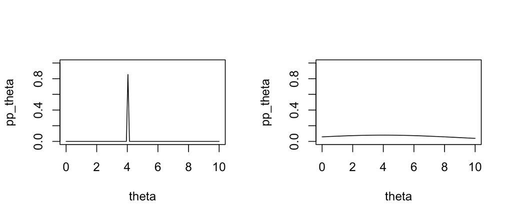

**Prior probability of $\theta$**

$Pr[\theta]$ is the *prior* probability of $\theta$ and should according to Bayesian statistics reflect what we know (or believe to know) about how close $\theta$ is to the true parameters. We can use information from previous studies or we can assign a *uninformative* prior, e.g., $Pr[\theta]$ follows a uniform distribution for all $\theta$ in the interval $[a,b]$.

It can be shown that the effect of the prior on the posterior probbility is largest when the observed data is small. With larger sample sizes, the posterior probability will eventually just depend on $Pr[D|\theta]$.

**Marginal Probability of $D$**

$Pr[Y|X]=\int_{\theta}Pr[Y| X, \theta]Pr[\theta]$ is the probability of $Y|X$ regardless of $\theta$. This can often be difficult difficult to calculate and, for this reason, Bayesian models are often designed so that this can be calculated analytically or using some approximation approach, such as Markov chain Monte Carlo (MCMC) is used.

**Extra Reading**

**Probabilistic algebra**

A conditional probability $Pr[A|B]$ is the probability that $A$ happens if we know that $B$ has happened. To obtain the probability that both $A$ and $B$ happens we need to first take the probability that $B$ happens and then multiply it with the conditional probability that $A$ hapens given $B$, i.e.:

$$Pr[A,B] = Pr[A|B] Pr[B].$$

From this follows the reverse operation

$$\frac{Pr[A,B]}{Pr[B]} = Pr{A|B}$$
Notice that this also works if we have more than one condition: $Pr[A|B,C] * Pr[B] = Pr[A,B|C].$

What happens in Bayes rule is that we first, in the numerator, perform $Pr[B|A]*Pr[A] = Pr[A,B]$ and then divide this with the denominator $\frac{Pr[A,B]}{Pr[B]} = Pr[A|B]$.

## Bayesians vs frequentists

**Lecture notes**

There is often described a severe controversy between Bayesians and frequentists. However, this controversy represents the extreme hardcore Bayesians and frequentists.

In reality, there is a large gray-zone where frequentists and Bayesians meet and socialize:

- Bayesian models can be viewed as a type of the hierarchical models often used by frequentists
- The likelihood could be interpreted as an unnormalized posterior probability under an uninformative prior
- Frequentist bootstrap analysis is often used to estimate uncertainty of point estimates in relation to alternatives, similarly to what is done in Bayesian statistics
- Conversely, the maximum *a posteriori* estimate is a point estimate, similar to the MLE
- Bayesian *posterior intervals* corresponds to frequentist *confidence intervals* (*Note* however, that there are no Bayesian significance test)
- The *Bayes factor* is a Bayesian version of the likelihood ratio
- etc.

Most practical statisticians use the tool that is adequate for the problem at hand, whether it is Bayesian or frequentist.

# Overfitting

We will now look at a general problem in statistical modeling that can be visualized quite well with Likelihoods. We will later look at some solutions to this problem.

## Overfitting | `Example data`

First, you need some test data to play around with. For simplicity and convenience, you will simulate a toy data from a linear model and use this in the exercises. The advantage for us using simulated data is that we know the ‘truth’, i.e., how the data was simulated and we therefore have *oracle knowledge* about the true parameter values, e.g., for $\beta$.

### Task | `simulation of example data`

- The data should comprise 100 samples.
- First generate 10 variables $(x_1,x_2,\ldots, x_{0})$ from a uniform distribution (use the function `runif`) and store them in a Matrix $X$.
- Use an intercept $\beta_0=3$
- Generate effect sizes $\beta_1, \beta_2, \beta_3$ from a Uniform distribution in the interval $(0.5, 1.0)$ for the 3 first $X$ variable (use the function `runif`); record the ‘true’ effect sizes for reference.
- Finally generate outcome variable $Y$ using a linear model $Y = \beta_0 + \beta_1 x_i + \beta_2 x_2 + \beta_3 x_3 + \epsilon$, with $\epsilon\sim N(0,\sigma^2=1)$ (i.e., the residuals are drawn from a Normal distribution with mean=0 and standard deviation=1, *Tip:* use the R function `rnorm`).

```r
# To obtain exactly the same result as in the demo, set seed to 85
set.seed(85)
```

```r
N=100 # number of samples
P=10 # number of variables

# Draw variables, x_{i,1},...,x_{i,P} for all N individuals, from a uniform distribution in interval (0,1) (this is the default interval for runif)
# 1. runif generates N*P+1 values, round them off to 2 decimals
# 2. Put values into a matrix with N rows and P columns
X=matrix(round(runif(N*(P+1),min=0, max=2)), nrow=N, ncol=P)

# generate a y variable from a multivarite lm of 3 first X variables only
# intercept
b0=3
# effect sizes for first three variables
b=c(runif(3, min=0.5, max=1.0))

# generate y for all samples (=rows in X) using only the 3 first variables (columns) of X
Y <- b0 + X[,1] * b[1] + X[,2] * b[2] + X[,3] * b[3] + rnorm(N)
```

#### Think about:

- What can simulation be used for?

**Some possible answers**

#### Some possible answers

- Oracle knowledge when evaluating performance of methods, e.g., Type I and II errors
- Estimating probabilities and probability distributions of, e.g., data and summary statistics of data

## Overfitting | `Model comparison`

Now consider the following two models for our data

$$\begin{eqnarray}
y & \sim & \beta_0 + \beta_1 x_1 & (1) \\
y & \sim & \beta_0 + \beta_1 x_1 + \beta_2 x_2 & (2)
\end{eqnarray}$$

What are the max Likelihood estimates of the two models? (we can use the R function `logLik` in the `stats` package)

### Task | `plot two likelihoods`

- Create `lm` models for the two models, and
- store the likelihood (use `logLik`) in a vector
- plot the likelihoods

```r
library(stats)
ll= vector()
for(i in seq(1,2)){
  Xi=X[,seq(1,i)] # use variables 1..i
  ll[i] <- logLik(lm(Y~Xi)) # logLik extract loglikelihood from lm
}
# plot likelihoods for models with 1 and 2 variables
plot(ll, ylab="log L", xlab="model #", type = "b", xlim=c(1,P), ylim=c(floor(min(ll)),ceiling(max(ll))))
# xlim and ylim not really necessary here, but I can reuse the plot statement below, so the plots look similar
```

**Show result**

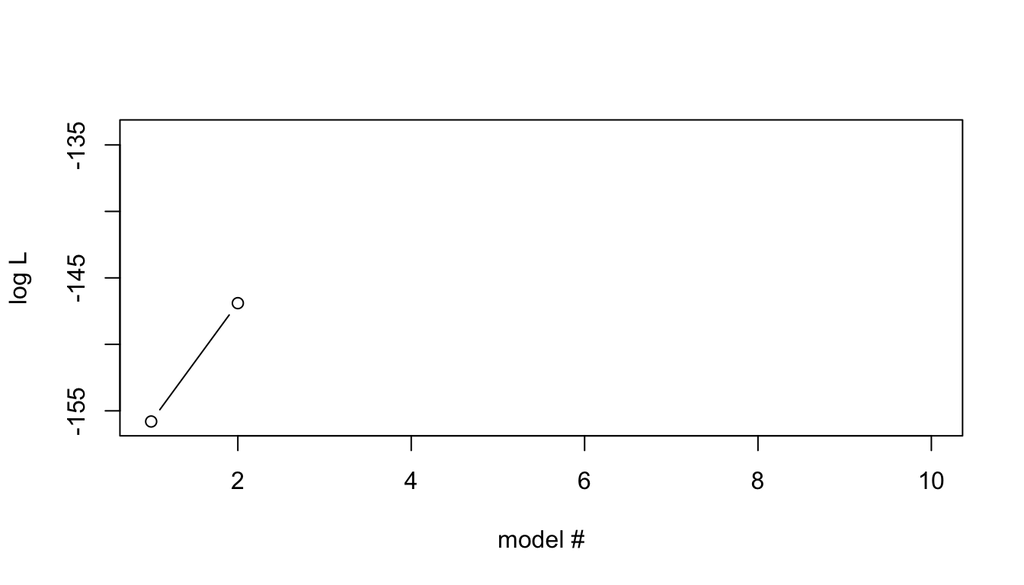

… 2 variables are clearly better than 1 variable – What if we add more variables?

### Task | `plot all likelihoods`

- Now repeat this for the sequence of models obtained by creating the next model by simply adding the next $X$ variable in order.

```r
# compute loglikelihood (ll) for all models including variables
# 1-i, for i <= P; store results in vector ll
ll= vector()
for(i in seq(1,P)){
  Xi=X[,seq(1,i)]
  ll[i] <- logLik(lm(Y~Xi))
}

# plot ll for all models
plot(ll, ylab="log L", xlab="model #", type = "b", xlim=c(1,P), ylim=c(floor(min(ll)),ceiling(max(ll))))
```

**Show result**

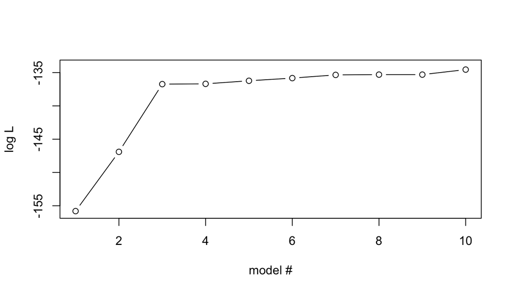

#### Think about:

- How does the Likelihood behave as more variables are added?
- Which is the maximum likelihood model? Is this correct given our *oracle knowledge*?
- What could be the problem with this behaviour? How would we like it to behave?
- How can we obtain the desired behaviour?

**Some possible answers**

#### Some possible answers

*Nested models*

- Model (1) can be described as a special case of Model (2) with the constraints on $\beta_2=0$
- Therefore Model (2) will always have equal or better ML than Model (1)

*Overfitting*

- Using our *oracle knowledge*, we know that the simulated data was generated from the 3 first variables
  - thus, the subsequent variables increase ML by modeling noise in data
- This is difficult to detect by just looking at the likelihoods
- Solutions
  - Seek the simplest model that is “good enough” -> Regularization

**Extra Reading**

## Model comparison | `Likelihood ratio test` For nested models $-2 \max LRT$ is $\chi^2(d)$-distributed, with $d=$ the difference in free params in the two models. Compared models logL 1st model logL 2nd model logLR P-value Sign at 0.05 1 vs 2 variables -155.80 -146.90 -8.9 2.45e-05 yes 2 vs 3 variables -146.90 -136.73 -10.17 6.48e-06 yes 3 vs 4 variables -136.73 -136.69 -0.04215 0.772 no 4 vs 5 variables -136.69 -136.23 -0.4601 0.337 no 5 vs 6 variables -136.23 -135.83 -0.4016 0.37 no 6 vs 7 variables -135.83 -135.35 -0.4803 0.327 no 7 vs 8 variables -135.35 -135.31 -0.04266 0.77 no 8 vs 9 variables -135.31 -135.30 -0.0002981 0.981 no 9 vs 10 variables -135.30 -134.55 -0.7536 0.22 no In our simple test case, the LRT also succeed in picking the correct model. It should be noted that certain issues, such as *linkage disequilibriium*, may cause problems for LRT (*the example is not optimized to show this*).

# Regularization

**Lecture notes**

Regularization is a concept that adds auxiliary criteria, so-called *regularization terms*, to probabilistic models. This is called regularized likelihood models or penalized likelihood models. Typically, the regularization term is a function of parameters $\beta$:

$$\log rL[\beta | X, Y] = \log L[\beta | X, Y] - f(\beta),$$

A very simple regularized likelihood model uses $f(\beta) = \#\beta = \#X$, that is the number of $X$ variables.
$$\log rL[{\beta} | X, Y] = \log L[\beta | X, Y] - \#X,$$

Applying this rL to our example data, solves the overfitting problem.

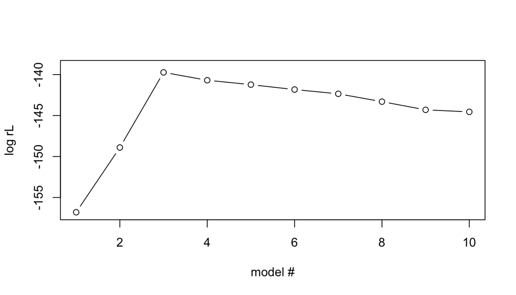

```r
# compute loglikelihood (ll) for all models including 1-P variables
rl= vector()
for(i in seq(1,P)){
  xi=X[,seq(1,i), drop=FALSE]
  fit = lm(Y~xi)
  # Compute the regularized Likelihood
  rl[i] = logLik(fit) - i
}
# plot ll of all models
plot(rl, xlim=c(1,P), ylim=c(floor(min(rl)),ceiling(max(rl))),ylab="log rL", xlab="model #", type = "b")
```

## Regularization | `Bayesian interpretation`

**Lecture notes**

Regularization is a canonical example where Bayesian and frequentist statistics meet.

The standard way of writing a regularized likelihood is using the logLikelihood, but what if we ‘de-log’ it:

$$\begin{eqnarray*}
\log rL[\beta | X, Y] &= \log L[\beta | X, Y] - f(\beta) &=\log Pr[Y | X, \beta] - f(\beta) \\
&\Downarrow\\
rL[\beta | X, Y] &= L[\beta | X, Y]\times e^{-f(\beta)}&= Pr[Y | X, \beta] \times e^{- f(\beta)}
\end{eqnarray*}$$

This looks suspiciously like an un-normalized posterior probability (i.e., lacking the denominator), with an exponential prior $Pr[\beta]=e^{-f(\beta)}.$

As we will see examples of, most regularization techniques have a Bayesian interpretation.

In fact, a standard solution to overfitting and, more generally, over-parameterization, i.e., problems where the likelihood function may not have a unique maximum, is to include prior information, either as Bayesian priors or regularization terms to limit the parameter space. This is an area where Bayesian and frequentist socialize and get on well.

## Regularization | `AIC and model testing`

**Lecture notes**

Coming from a *information theory* base, Hirotugu Akaike came up with a very similar approach for the overfitting problem.

The Akaike information criterion (AIC), for a model $m$ with variables $X$, is defined as

$$AIC_m = 2\# X - 2\log \max L[{\beta}|X,Y]$$

We see that $AIC_m = -2 \left(\log \max L[{\beta}|X,Y] - \#X\right)$, i.e., $-2$ times the the simple $\log rL$, we just looked at in our first regularization example.

**Extra Reading**

From a information theory perspective, the difference in $AIC$ between two models is claimed to estimate the information lost by selecting the worse model.

Sometimes, the *relative likelihood* for model $m$ is used, which is
$$relL = e^\frac{ AIC_{min} - AIC_{m} }{2}$$
where $AIC_{min}$ is the minimum AIC among a set of compared models

**Extra Reading**

- $relL$ can be interpreted as proportional to the probability that the model $m$ minimizes the information loss.
  - Notice that,
    $$relL = \frac{\max L[{\beta}_{m}|X_m,Y]}{\max L[{\beta}_{min}|X_{min},Y]} \times e^{-\left(\#X_{m}-\#X_{min}\right)}$$

  we see that $rL$ can be viewed as a likelihood ratio weighted by a function of the difference in number of $X$ variables.
- However, AIC are not limited to nested models

### Task | `AIC analysis`

- A typical strategy is to select the model, $m$ with $AIC_m=AIC_{min}$ and then evaluate how much better it is than the other candidate models, e.g., using the $relL$.
- Apply this AIC strategy applied to our example data using the R funcion `AIC`
- create a table with the AIC and the $relL$ for the set of models comprising $\{X_1, .\ldots, X_i\} \textrm{ for } i \in [1, \ldots, 10]$; indicate also if a model is the minimum AIC model.

```r
library(stats)
library(dplyr)      # used for nice table formatting
library(kableExtra) # used for nice table formatting

mprev <- lm(Y ~ X[,1]) # current miminimum AIC model
# dummy entry to be replaced
aic=data.frame(models=0, aic=0, isAICmin="-")

for(i in seq(1,P)){
  m <- lm(Y ~ X[,seq(1,i)])
  fit = AIC(mprev,m)
  mprev = m
  if(i==2){ #include also the first model
    aic[i-1,] = list(paste0(i-1," variable"), signif(fit$AIC[1],5), "-")
  }
  aic[i,] = list(paste0(i," variables"), signif(fit$AIC[2],5), "-")
}
# Identify the model with min AIC and compare all others to that
minaic=min(aic$aic)
aic$relL=format(exp((minaic-aic$aic)/2), digits=4)
aic$isAICmin = ifelse(aic$aic==minaic,"Yes","-")

kable(aic, format='html', row.names=F,
      col.names=c("Compared models","AIC","Minimum AIC","relL"))%>%
  kable_styling( font_size = 14)
```

**Show result**

Compared models

AIC

Minimum AIC

relL

1 variable

317.61

3.841e-08

2 variables

301.80

1.041e-04

3 variables

283.46

Yes

1.000e+00

4 variables

285.38

3.829e-01

5 variables

286.46

2.231e-01

6 variables

287.66

1.225e-01

7 variables

288.70

7.280e-02

8 variables

290.61

2.802e-02

9 variables

292.61

1.031e-02

10 variables

293.10

8.067e-03

- Try to plot the $AIC$ and the $relL$ with the different models on the $X$-axis

```r
library(stats)

# plot AIC of all models
plot(aic$aic, xlim=c(1,P),
     ylim=c(floor(min(aic$aic)), ceiling(max(aic$aic))),
     ylab="AIC", xlab="model #", type = "b")

# plot relL of all models
plot(aic$relL, xlim=c(1,P),
     ylab="relL", xlab="model #", type = "b")
```

**Show result**

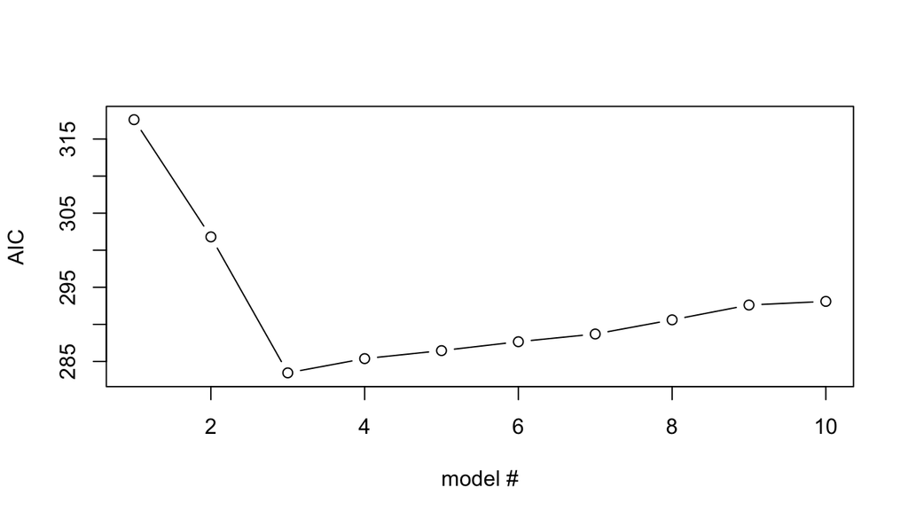

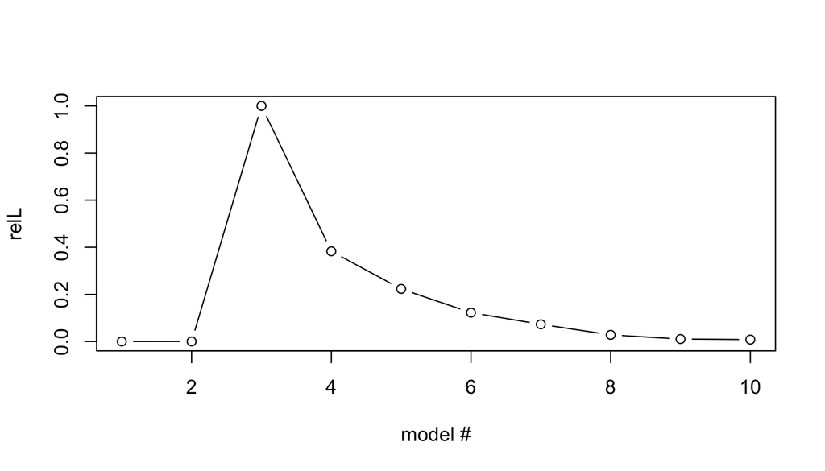

#### Think about:

- Which is the best model? Is this correct compared to our *oracle knowledge*?
- How good is it compared to the others?
- Can you see a drawback in our model testing approach above? If so, how can we solve that?

**Some possible answers**

#### Some possible answers

- We see that the best model is the one with the 3 first X-variables (in line with our *oracle knowledge*) and that the second best model (with the first 4 X-variabels) is $\approx60\%$ worse.

**Extra Reading**

- Sometimes it is desirable to compute a significance for rejecting a model in favour of another model. A NULL distribution for the $relL$ statistic is usally obtained through simulation, e.g., using parameteric bootstrapping.
- Now, I this case we happened to know that the first 3 variables was the right one, so the order we choose to include them was correct. However, in the general case, we do not know this. How solve this?
  - Best subset method; involves testing all possible subsets, which is computationally time-consuming and dometimes unfeasible
  - Lasso

## Regularization | `LASSO and Feature selection`

**Lecture notes**

LASSO stands for Least absolute shrinkage and selection operator (“shrinkage” is another common term for regularization) and is a method for selecting variables to include in a multivariate model.

Here, we do nott explicitly compare two models with different number of variables. Instead all variables are included and the regularization acts upon the values of $\beta$ so that only important variabels have a $\beta_i> 0$.

Classical LASSO builds on RSS of a linear regression model $Y \sim X{\beta}$ with regularization

**Extra Reading**

Extensions to glms exists, but then using a regularized likelihood expression

The regularization term $f(\beta) = \lambda\sum_{\beta_i\in\beta} |\beta_i|$

**Extra Reading**

Often the regularization term is expressed in terms of the $\ell_1-norm$, which can be viewed simply a short-hand notation, e.g., the $\ell_1-norm$ of $\beta$ is
$$||\beta||_1 = \sum_{\beta_i\in\beta} |\beta_i|$$

There is also a $\ell_2-norm$:
$$||\beta||_2 = \sqrt{\sum_{\beta_i\in{\beta}} \beta_i^2}$$
which is used, e.g., in ridge regression.

We note, BTW, that you already have been working with an $\ell_2-norm$: since $RSS = ||Y-X\beta||_2^2$ is simply the square of the $\ell_2$ norm of the residuals.

The $\lambda$ parameter defines how strong the regularization becomes; a higher $\lambda$ will put a stricter limit on the estimation of individual $\beta_i$ values.

Lasso is traditionally described as RSS with an auxiliary criterion/constraint:

$$min\left\{RSS\right\} + \lambda\sum_{\beta_i\in\beta} |\beta_i|,$$
but, equivalently, it can be written in terms of the likelihood:
$$max \log L[\beta|X,Y] - \lambda\sum_{\beta_i\in\beta} |\beta_i|.$$
Lasso can also be viewed as a un-normalized Bayesian posterior probability, with a LaPlacean prior on $\beta$: $\beta_j ∼ LaPlace(0, 1/\lambda)$

**Extra Reading**

Other common notation for LASSO:

- You might often see the notation
  $$min_{{\beta}}\left\{RSS\right\} \textrm{ subject to } ||{\beta}||_1 <= t$$
  where $t$ is related to $\lambda$.

The optimal values of $\beta$ are then estimated, using some algorithm (lars or coordinate descent).

**Extra Reading**

The *Coordinate descent* algorithm is used in the R package `glmnet`:

**Extra Reading**

Alternatives to LASSO, differing mainly in the auxiliary criterion, include

- *Ridge regression* which uses a $\ell_2$ norm
- *Elastic-net*, which uses a mixed model combination of the $\ell_1$ norm and the $\ell_2$ norm

(both these are implemented in the R package `glmnet`, which we will use below). ***

### Task | `Lasso using the glmnet R-package`

- Use function `glmnet` to perform LASSO analysis on our example data; relevant arguments of the function:
  - linear regression (`family='gaussian'` = default)
  - LASSO (`alpha=1` = default)
  - standardization
    - The variables Y and X must be centered and standardized to ensure that all variables are given equal weight in the model selection.
    - standardization of $X$ to unit variance in `glmnet` is obtained by setting the argument `standardize=TRUE` which is the default
    - the values of $Y$ is always standardized (?) for `family=gaussian` (LASSO)
    - and the coefficients are back-standardized before reported

**Extra Reading**

Standardization in `glmnet`: $x' = \frac{x-\bar{x}}{1/\sqrt{N}||X-\bar{x}||_2}$

```r
library(glmnet)
# run lasso (alpha=1) for linear model (family=gaussian)
fit = glmnet(X,Y, family="gaussian", alpha=1, standardize=T)
```

- A graphical way to view the result is to `plot` the paths of $\beta$ for increasing vaules of $\lambda$. This plot shows how the $\beta_i$ for different variables changes with $\lambda$. The plot is perhaps best read from right to left, going from higher and thereby stricter, $\lambda$ values to lower $\lambda$ values including more and more variables/non-zero $\beta_i$.

```r
par(mfrow=c(1,1))
plot(fit, xvar="lambda",label=T)
```

**Show result**

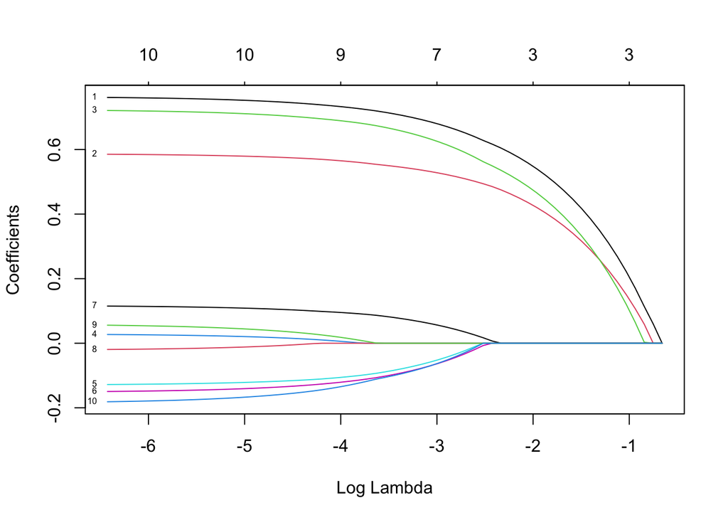

#### Think about

- In which order are variables included (i.e., their $\beta$ becomes non-zero?
- In which direction is the effect
- Which lambda should we select?
  - Given our *oracle knowledge*, where would an appropriate $\lambda$ be?
  - Can we use that in the general case?

**Some possible answers**

#### Some possible answers

- The order appears to be $(1,2,3,7,6,5,10,9,4,8)$
- $\beta_i > 0, i\in \{1,2,3,4,7,9\}$, while $\beta_i<0, i\in \{5,6,8,10\}$
- Given *oracle knowledge*, the correct $\lambda$ appears lie somewhere in the interval $[\approx \exp(-1), \approx\exp(-2.5)]$
- In the normal case, we do not have *oracle knowledge*.

## Cross-validation

**Lecture notes**

The LASSO model will be different depending on how we set $\lambda$. A problem is to decide the optimal $\lambda$ to use.

- $\lambda$ too *high*: risk of missing relevant variables
- $\lambda$ too *low*: risk of overfitting

`glmnet` addresses this using *$k$-fold cross-validation* – what is that?

### Cross-validation | `How to test for overfitting`

**Lecture notes**

The ultimate way of testing an estimated model (with parameters) is to apply it to new data and evaluate how well it performs, e.g., by measuring the *mean squared error*, $MSE$ ($=RSS/N$). Naturally, we want to minimize $MSE$, i.e., the error of the model. In our LASSO application, this means that we want to select the $\lambda$ that minimizes the $MSE$

In cross validation, this approach is emulated by partioning the data at hand into a *training* and *validation* data set. The model parameters are estimated (‘trained’) on the the training data and the validated on the validation data. (Optionally, a *test* partition can be assigned in cross-validation on which the final, selected model is evaluated; this is not employed here).

By chance, this may fail if the partitioning is ‘non-representative’. A solution is to repeat the cross-validation procedure with another partioning.

In $k$-fold cross validation, the original data is split into $k$ sub-datasets $\{D_1,D_2,\ldots, D_k\}$. For $i \in \{1,2,\ldots, k\}$, set $D_i$ as the validation data set and the union of the other datasets be the training data. Perform cross validation as above.

This gives a distribution of $MSE$ from which we can estimate, e.g., mean and standard deviation.

**Extra Reading**

This distribution allows us to use more elaborate means to select $\lambda$. One common suggestion is to use the largest $\lambda$ whose $MSE$ is within 1 standard error from the minimum value (called `lambda.1se` in `glmnet`). The motivation argued for this choice is *parsimony*, in the sense that larger $\lambda$ will include fewer variables (hence it is parsimonious in terms of number of included variables).

Here we will limit ourselves to finding the minimum $\lambda$, called `lambda.min` in `glmnet`, but anyone is free to test if `lambda.1se` gives a different result.

### Task | `Determine optimal LASSO`$\lambda$`using cross-validation`

- Use the function `cv.glmnet` to perform cross validation (same options as for `glmnet`), store it in a R variable, e.g., `cvglm`,
- `plot` the cross-validation results
- Compare with the plot of estimated $\beta_i$ under different $\lambda$ (these can be accessed from the result as `cvglm$glmnet.fix`).
- Determine the optimal $\lambda$ (the one with minimal error, can be found in `cvglm$lambda.min`)

```r
library(glmnet)
par(mfrow=c(1,1))
# run lasso (alpha=1) for linear model (family=gaussian)
cvglm=cv.glmnet(X,Y, family="gaussian", alpha=1, standardize=T, nfolds=100)

plot(cvglm)
plot(cvglm$glmnet.fit, xvar="lambda",label=T)
minlambda=cvglm$lambda.min
print(minlambda)
```

**Show result**

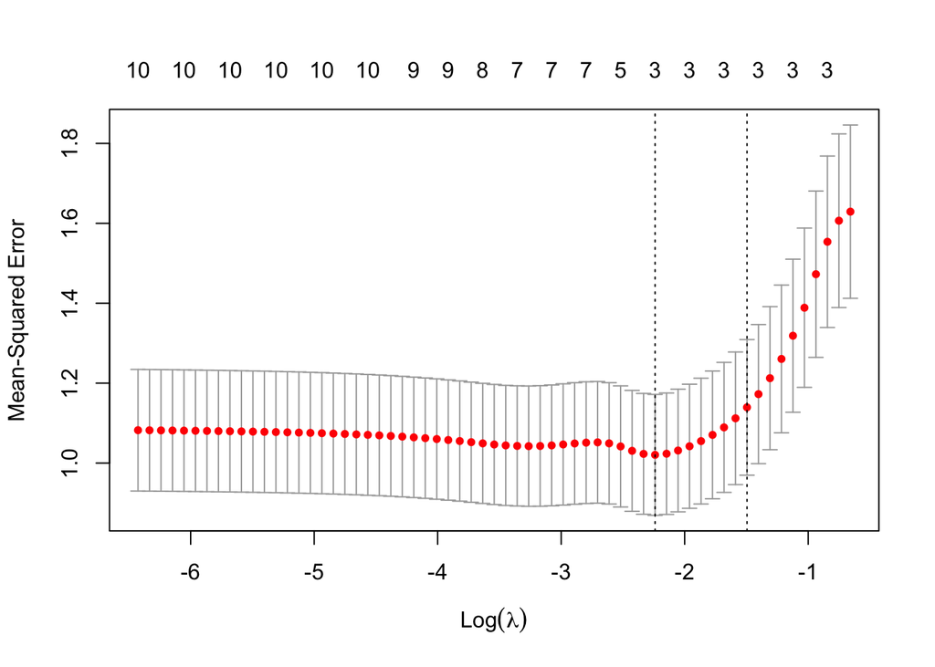

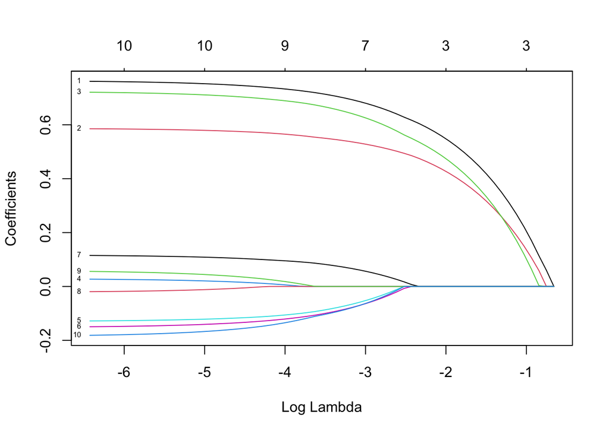

```
## [1] 0.1064891
```

#### Think about

- Which is the $\lambda$ selected by `cv.glmnet`?
- Does this make sense given our *oracle knowledge*?

**Some possible answers**

#### Some possible answers

- Cross-validation-selected optimal lambda is 0.1064891
- Yes, this includes only the *oracle knowledge* correct variables $X_1, X_2, X_3$

### Task| `Final LASSO effect sizes`

- Finally print a table with the $\beta$ coefficients (including the intercept, $\beta_0$) for the optimal model (i.e., at minimum $\lambda$); compare with oracle knowledge. (Hint: see `? coef.cv.glmnet`).

```r
# Actually the following suffice for output on console
#coef(cvglm, s="lambda.min")

# But to get a nice table:
library(dplyr)      # for nice table
library(kableExtra) #for nice table

coefglm=as.data.frame(as.matrix(coef(cvglm, s="lambda.min")))
coefglm=cbind(seq(0,10),c(b0, b, rep(0, 7)),coefglm)
names(coefglm)=c("beta","value (oracle)", paste0("estimate(lambda=",signif(minlambda,3),")"))
kable(coefglm, row.names=F) %>%   kable_styling( font_size = 14)
```

**Show result**

| beta | value (oracle) | estimate(lambda=0.106) |
| --- | --- | --- |
| 0 | 3.0000000 | 3.6046135 |
| 1 | 0.8125118 | 0.5905522 |
| 2 | 0.6009469 | 0.4631531 |
| 3 | 0.7232911 | 0.5204561 |
| 4 | 0.0000000 | 0.0000000 |
| 5 | 0.0000000 | 0.0000000 |
| 6 | 0.0000000 | 0.0000000 |
| 7 | 0.0000000 | 0.0000000 |
| 8 | 0.0000000 | 0.0000000 |
| 9 | 0.0000000 | 0.0000000 |
| 10 | 0.0000000 | 0.0000000 |

#### Think about

- Does the effect sizes make sense – if not can you think of why?

**Some possible answers**

#### Some possible answers

- Well…yes!
  - $\beta_i$ is non-zero only for *oracle*-known variables $X_1, X_2, X_3$
  - they don’t exactly equate our *oracle knowledge* parameter values – they appear to be scaled.
  - but their relative order of amplitude is right.
- Perhaps the normalization affected scaling.

# Exercises

We will here use biological experimental data, more specifically a skeletal muscle gene expression subset (randomly sampled 1000 genes) from GTEX Human Tissue Gene Expression Consortium ([Lonsdale et al. 2013](https://www.nature.com/articles/ng.2653)). We will use the approaches we learned above to perform feature selection on this data with respect to a logicit regression analysis.

### Task| `Load the GTEX muscle expression data`

- Load the data from the file `GTEX/GTEX_SkeletalMuscles_157Samples_1000Genes.txt` into a data.frame `X`.
- Check the dimensions of `X`
- Optionally, you can preview `X` using the function `datatable(X)`:

```r
X<-read.table("GTEX/GTEX_SkeletalMuscles_157Samples_1000Genes.txt", header=TRUE, row.names=1, check.names=FALSE, sep="\t")
X<-X[,colMeans(X)>=1]

dim(X)
library(DT)
datatable(X)
```

**Show result**

```
## [1] 157 546
```

|  | ENSG00000243824.1_RP11-434O22.1 | ENSG00000140527.10_WDR93 | ENSG00000205352.6_PRR13 | ENSG00000114850.2_SSR3 | ENSG00000008056.8_SYN1 | ENSG00000258413.1_RP11-665C16.6 | ENSG00000230561.3_CTC-228N24.1 | ENSG00000260244.1_RP11-588K22.2 | ENSG00000261611.3_AC010547.9 | ENSG00000198911.7_SREBF2 | ENSG00000100462.11_PRMT5 | ENSG00000228728.1_RP11-316K19.3 | ENSG00000106006.5_HOXA6 | ENSG00000048828.12_FAM120A | ENSG00000236021.1_RP11-195C7.1 | ENSG00000117016.5_RIMS3 | ENSG00000164896.15_FASTK | ENSG00000228703.1_RP5-1160K1.6 | ENSG00000272100.1_RP11-155O18.6 | ENSG00000236733.1_RP11-203L2.4 | ENSG00000116688.12_MFN2 | ENSG00000101082.9_SLA2 | ENSG00000183808.7_RBM12B | ENSG00000107295.8_SH3GL2 | ENSG00000152939.10_MARVELD2 | ENSG00000163785.8_RYK | ENSG00000186017.10_ZNF566 | ENSG00000130520.5_LSM4 | ENSG00000231007.4_CDC20P1 | … |
| --- | --- | --- | --- | --- | --- | --- | --- | --- | --- | --- | --- | --- | --- | --- | --- | --- | --- | --- | --- | --- | --- | --- | --- | --- | --- | --- | --- | --- | --- | --- |
| GTEX-N7MS-0426-SM-2YUN6 | 2 | 2 | 543 | 1832 | 5 | 0 | 11 | 151 | 2 | 3355 | 1898 | 0 | 63 | 5798 | 1 | 52 | 8964 | 46 | 93 | 2 | 22222 | 8 | 7 | 6 | 6 | 966 | 222 | 3424 | 26 | … |
| GTEX-NFK9-0626-SM-2HMIV | 0 | 0 | 1482 | 3444 | 20 | 0 | 2 | 261 | 1 | 5162 | 3573 | 2 | 19 | 6928 | 0 | 67 | 6310 | 19 | 170 | 1 | 16577 | 1 | 2 | 9 | 5 | 1882 | 236 | 3088 | 21 | … |
| GTEX-NPJ8-1626-SM-2HMIY | 0 | 3 | 1958 | 2967 | 13 | 0 | 2 | 76 | 0 | 5985 | 7103 | 2 | 27 | 14105 | 0 | 43 | 2543 | 31 | 147 | 1 | 14420 | 1 | 20 | 13 | 9 | 1613 | 282 | 1413 | 17 | … |
| GTEX-O5YT-1626-SM-32PK6 | 0 | 0 | 1174 | 3509 | 2 | 1 | 10 | 254 | 0 | 4772 | 3746 | 0 | 137 | 11878 | 0 | 63 | 4133 | 40 | 86 | 4 | 24965 | 0 | 15 | 13 | 0 | 1661 | 218 | 1346 | 19 | … |
| GTEX-OHPM-1626-SM-2HMK4 | 0 | 7 | 1092 | 2510 | 10 | 0 | 6 | 107 | 2 | 5174 | 4765 | 0 | 13 | 7648 | 1 | 57 | 4903 | 16 | 143 | 0 | 22405 | 2 | 2 | 23 | 14 | 1218 | 302 | 2490 | 17 | … |
| GTEX-OIZG-1326-SM-2HMIQ | 0 | 4 | 884 | 2718 | 9 | 0 | 8 | 153 | 1 | 4392 | 2913 | 0 | 14 | 6985 | 2 | 47 | 6160 | 7 | 157 | 0 | 23424 | 2 | 3 | 6 | 7 | 1481 | 280 | 2767 | 18 | … |
| GTEX-OIZH-1626-SM-2HMKI | 0 | 3 | 669 | 2901 | 9 | 2 | 15 | 173 | 1 | 4980 | 2904 | 0 | 54 | 8733 | 0 | 38 | 5035 | 38 | 91 | 1 | 26741 | 4 | 11 | 3 | 3 | 1755 | 360 | 2532 | 13 | … |
| GTEX-OIZI-0626-SM-2XCEH | 0 | 17 | 1260 | 4761 | 12 | 2 | 2 | 75 | 5 | 2911 | 2934 | 7 | 23 | 4780 | 0 | 76 | 3073 | 11 | 114 | 2 | 17424 | 0 | 7 | 20 | 3 | 1269 | 478 | 1326 | 23 | … |
| GTEX-OOBJ-1626-SM-2I3F7 | 0 | 6 | 1394 | 3472 | 11 | 0 | 31 | 121 | 0 | 4454 | 4602 | 2 | 69 | 6806 | 0 | 46 | 4013 | 21 | 156 | 2 | 19932 | 1 | 6 | 19 | 0 | 1839 | 314 | 2343 | 7 | … |
| GTEX-OOBK-1626-SM-2HMKG | 3 | 0 | 993 | 2613 | 22 | 3 | 27 | 130 | 0 | 5057 | 5329 | 3 | 31 | 8254 | 0 | 31 | 6103 | 29 | 127 | 2 | 25252 | 3 | 2 | 14 | 2 | 1371 | 170 | 2323 | 12 | … |

[output cut: 147 more lines]

#### Think about

- What are the dimensions of `X`? What does this mean for multivariate analysis?

**Some possible answers**

#### Some possible answers

- We can see that the gene expression data set includes p = 546 expressed genes (features) and n = 157 samples, i.e., there are more variables than samples (p >> n).
- We do not have power to estimate a multivariate model including all variables; we need to do feature selection.

The phenotype of interest that we address address is *Gender*, i.e. we will figure out which of the 546 genes expressed in human skeletal muscles drive the phenotypic difference between Males and Females.

### Task| `Load the GTEX Gender data`

- Load the Gender data for the GTEX samples from the file `GTEX/GTEX_SkeletalMuscles_157Samples_Gender.txt` in to a variale `Y` (Hint: keep only the variable `Gender`)
- Check that the the number of samples corresponds to `X` and how many women and men there are.

```r
Y<-read.table("GTEX/GTEX_SkeletalMuscles_157Samples_Gender.txt", header=TRUE, sep="\t", stringsAsFactors=TRUE)$GENDER

summary(Y)
length(Y)
```

**Show result**

```
## Female   Male
##     58     99
```

```
## [1] 157
```

The samples includes 99 Males and 58 Females, it is not perfectly balanced but still not too bad.

### Task| `Visualize the data`

- Do a PCA analysis of `X` and color/group them by `Y`
- Do a barplot of explained variance per principal component

```r
pca.gtex <- prcomp(X, scale=TRUE, center=TRUE)

# sample plot
pca_plot <- data.frame(x = pca.gtex$x[,"PC1"], y = pca.gtex$x[,"PC2"], Groups = Y)
ggplot(pca_plot) +
  geom_point(aes(x=x, y=y, color=Groups)) +
  scale_color_manual(values=c("red","blue")) +
  ggtitle(label="PCA on GTEX Skeletal Muscles") +
  xlab("PC1") +
  ylab("PC2") +
  theme_bw() +
  theme(title=element_text(face="bold"))

# barplot prop variation explained
x = paste0("PC",1:10)
# calculate variation explained
y.var <- pca.gtex$sdev ^ 2
y.pvar <- y.var/sum(y.var)
y.pvar<-y.pvar*100

pc_plot=0
pc_plot = data.frame(x = factor(x, levels=x), y = y.pvar[1:10])
ggplot(data=pc_plot, aes(x=x, y=y)) +
  geom_bar(stat="identity") +
  ggtitle(label="PCA on GTEX Skeletal Muscles") +
  xlab("Principal Components") +
  ylab("Variation explained") +
  theme_bw() +
  theme(title=element_text(face="bold"))
```

**Show result**

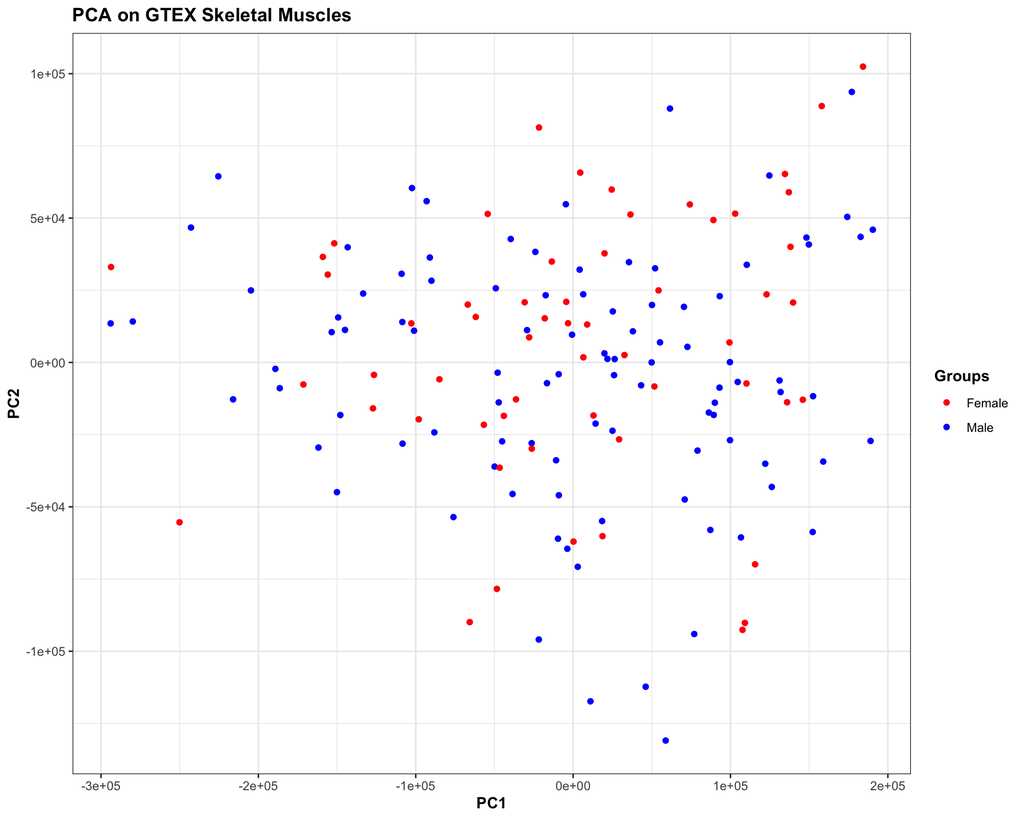

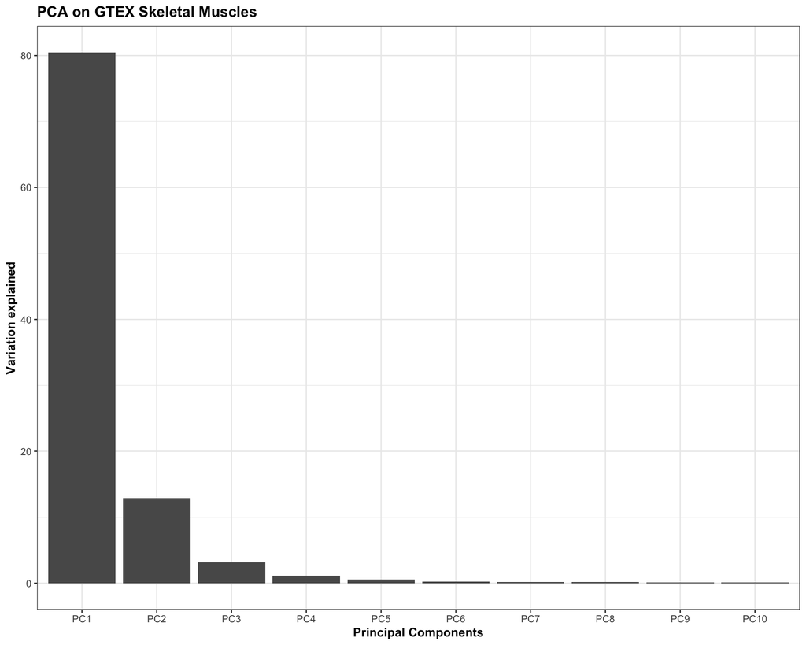

The PCA plot demonstrates that there is a lot of variation between samples with respect to both PC1 and PC2, but there is no clear segregation of Males and Females based on their skeletal muscle gene expression data.

We want to investigate if there are a subset of genes that are associated to the phenotype *Gender*, that is, we want to do find optimal multivariate regression analyses. Since *Gender* is a binary variable, it is appropriate to use logistic *GLM* (`glm` with `family=binomial()`) for all analyses. However, as suggested by the PCA, the majority of genes are probably not associated to *Gender*. Hence we want to perform *feature selection* to identify a, hopefully, optimal multivariate model to use.

## AIC

We will first try to use AIC to determine the best multivariate model. A main decision is to choose the order in which to add variables to models. To help with that, we will first perform univariate regressions.

### Task| `AIC`

- Perform separate univariate logistic regression ($logit(Y)\sim\beta X$) analyses for all genes of `X`
  - Collect the Gene name, P-values and Odds ratios (or alternatively the coeficients) in a data.frame *univariateResults* (one row per gene)
    - Hint: use `coef(summary(<your glm model>)` to extract P-values and coefficients
  - Also add a column with adjusted p-values to the data.frame
  - Optionally show the new data.frame in a `datatable`
- Write an R function `doAIC` that performs a AIC analysis on multivariate GLMs including sequentially more genes from a given matrix `myX` and a fixed outcome `mY` in the models.
  - Hints:
    1. Reuse code from the AIC task above.
    2. Use `myX[,seq(1, i)]` to get the use only the `i` first columns of `myX`.
    3. Use `as.matrix` to convert the given subsetted `X` data.frame to a matrix before using it in the GLM.
- Try to run `doAIC` using different orderings and subsets of `X` as `myX`, e.g.:
  - ordered by size of odds ratio, by P-value
  - top 20, top 100 or only significant P-values (unadjusted or adjusted)

**Possible solutions**

#### Univariate analysis

```r
coefs<-vector()
pvals<-vector()
a<-seq(from=0,to=dim(X)[2],by=100)
for(i in 1:dim(X)[2])
{
  model = glm(Y~X[,i], family=binomial)
  coefs=append(coefs, exp(coef(summary(model))[,1][2])) #
  pvals=append(pvals, coef(summary(model))[,4][2]) #
}
univariateResults<-data.frame(GENE=colnames(X), COEFFICIENTS=coefs, PVALUE=pvals)
univariateResults$FDR<-p.adjust(univariateResults$PVALUE,method="BH")
# Optional
datatable(univariateResults[order(-abs((1-univariateResults$PVALUE))),])
```

[output not shown]

#### doAIC function

```r
library(stats)
coef<-vector()
pval<-vector()
a<-seq(from=0,to=dim(X)[2],by=100)

doAIC<-function(myX, myY){
  myX = as.matrix(myX)
  mprev <- glm(myY ~ myX[,1], family=binomial()) # current miminimum AIC model
  # dummyentry to be replaced
  aic=data.frame(models=0, aic=0, isAICmin="-")
  for(i in seq(1,ncol(myX))){
    m <- glm(as.numeric(myY) ~ myX[,seq(1,i)]) #, family=binomial())
    fit = AIC(mprev,m)
    mprev = m
    if(i==2){ #include also the first model
      aic[i-1,] = list(paste0(i-1," variable"), signif(fit$AIC[1],5), "-")
    }
    aic[i,] = list(paste0(i," variables"), signif(fit$AIC[2],5), "-")
  }
  minaic=min(aic$aic)
  aic$rl=format(exp((minaic-aic$aic)/2), digits=4)
  aic$isAICmin = ifelse(aic$aic==minaic,"Yes","-")

  print("Best model is:")
  print(aic[aic$isAICmin == "Yes",])
  # Table of all models
  kable(aic, format='html', row.names=F, col.names=c("Compared models","AIC","Minimum AIC","rL"),digits=30,format.args=list(snsmall=0))  %>%  kable_styling( font_size = 14)
}
```

#### doAIC| `Sorted on *Odds ratio* -- top 20 genes`

```r
# Add variable according to their odds ratio in univariate logistic regression
# Use top 20 variables
univariateResults<-univariateResults[order(-abs((1-univariateResults$COEFFICIENTS))),]
doAIC(X[, head(univariateResults$GENE,20)], Y)
```

```
## [1] "Best model is:"
##        models    aic isAICmin        rl
## 5 5 variables 214.58      Yes 1.0000000
```

Compared models

AIC

Minimum AIC

rL

1 variable

218.11

0.1711868

2 variables

216.41

0.4005166

3 variables

217.32

0.2541070

4 variables

215.37

0.6736800

5 variables

214.58

Yes

1.0000000

6 variables

215.15

0.7520143

7 variables

216.77

0.3345396

8 variables

215.97

0.4990744

9 variables

215.46

0.6440364

10 variables

215.89

0.5194421

11 variables

217.72

0.2080452

12 variables

217.64

0.2165357

13 variables

219.13

0.1027969

14 variables

220.75

0.0457300

15 variables

222.12

0.0230521

16 variables

223.70

0.0104621

17 variables

224.73

0.0062511

18 variables

226.34

0.0027948

19 variables

228.34

0.0010281

20 variables

229.02

0.0007318

#### doAIC| `Sorted on *Odds ratio* -- top 100 genes`

```r
# Add variable according to their odds ratio in univariate logistic regression
# Use top 100 variables
univariateResults<-univariateResults[order(-abs((1-univariateResults$COEFFICIENTS))),]
doAIC(X[, head(univariateResults$GENE,100)], Y)
```

```
## [1] "Best model is:"
##          models   aic isAICmin        rl
## 92 92 variables 130.7      Yes 1.000e+00
```

Compared models

AIC

Minimum AIC

rL

1 variable

218.11

1.045e-19

2 variables

216.41

2.445e-19

3 variables

217.32

1.551e-19

4 variables

215.37

4.113e-19

5 variables

214.58

6.105e-19

6 variables

215.15

4.591e-19

7 variables

216.77

2.042e-19

8 variables

215.97

3.047e-19

9 variables

215.46

3.932e-19

10 variables

215.89

3.171e-19

11 variables

217.72

1.270e-19

12 variables

217.64

1.322e-19

13 variables

219.13

6.276e-20

14 variables

220.75

2.792e-20

15 variables

222.12

1.407e-20

16 variables

223.70

6.387e-21

17 variables

224.73

3.816e-21

18 variables

226.34

1.706e-21

19 variables

228.34

6.277e-22

20 variables

229.02

4.468e-22

21 variables

226.52

1.559e-21

22 variables

225.94

2.084e-21

23 variables

227.94

7.667e-22

24 variables

228.72

5.191e-22

25 variables

229.69

3.196e-22

26 variables

231.66

1.193e-22

27 variables

233.31

5.230e-23

28 variables

232.48

7.921e-23

29 variables

229.66

3.244e-22

30 variables

230.66

1.968e-22

31 variables

231.37

1.380e-22

32 variables

229.79

3.040e-22

33 variables

231.59

1.236e-22

34 variables

228.39

6.122e-22

35 variables

224.35

4.615e-21

36 variables

226.34

1.706e-21

37 variables

224.90

3.505e-21

38 variables

226.10

1.924e-21

39 variables

227.75

8.431e-22

40 variables

225.33

2.827e-21

41 variables

227.31

1.051e-21

42 variables

226.18

1.848e-21

43 variables

225.73

2.315e-21

44 variables

225.76

2.280e-21

45 variables

227.05

1.196e-21

46 variables

228.79

5.012e-22

47 variables

224.31

4.708e-21

48 variables

226.28

1.758e-21

49 variables

228.19

6.766e-22

50 variables

226.86

1.316e-21

51 variables

228.82

4.938e-22

52 variables

230.79

1.844e-22

53 variables

230.76

1.872e-22

54 variables

228.18

6.800e-22

55 variables

226.92

1.277e-21

56 variables

228.73

5.165e-22

57 variables

228.91

4.720e-22

58 variables

230.38

2.263e-22

59 variables

227.03

1.208e-21

60 variables

229.02

4.468e-22

61 variables

229.87

2.921e-22

62 variables

231.87

1.075e-22

63 variables

227.82

8.141e-22

64 variables

163.94

6.054e-08

65 variables

163.64

7.033e-08

66 variables

161.91

1.670e-07

67 variables

163.74

6.690e-08

68 variables

164.76

4.018e-08

69 variables

166.76

1.478e-08

70 variables

168.50

6.192e-09

71 variables

168.59

5.920e-09

72 variables

165.87

2.306e-08

73 variables

167.72

9.146e-09

74 variables

151.57

2.939e-05

75 variables

151.88

2.517e-05

76 variables

146.02

4.713e-04

77 variables

147.77

1.965e-04

78 variables

149.34

8.961e-05

79 variables

150.89

4.129e-05

80 variables

152.85

1.549e-05

81 variables

154.85

5.700e-06

82 variables

156.29

2.775e-06

83 variables

158.15

1.095e-06

84 variables

155.50

4.119e-06

85 variables

147.35

2.424e-04

86 variables

149.21

9.563e-05

87 variables

150.52

4.968e-05

88 variables

152.11

2.243e-05

89 variables

152.97

1.459e-05

90 variables

142.71

2.466e-03

91 variables

142.28

3.058e-03

92 variables

130.70

Yes

1.000e+00

93 variables

130.98

8.694e-01

94 variables

131.08

8.270e-01

95 variables

133.07

3.057e-01

96 variables

134.87

1.243e-01

97 variables

136.37

5.872e-02

98 variables

138.35

2.182e-02

99 variables

135.62

8.543e-02

100 variables

133.66

2.276e-01

#### doAIC| `Sorted on *P-value* -- top 20 genes`

```r
univariateResults<-univariateResults[order(univariateResults$PVALUE),]
doAIC(X[, head(univariateResults$GENE,20)], Y)
```

```
## [1] "Best model is:"
##          models    aic isAICmin        rl
## 13 13 variables 137.49      Yes 1.000e+00
```

Compared models

AIC

Minimum AIC

rL

1 variable

171.10

5.031e-08

2 variables

162.23

4.244e-06

3 variables

158.89

2.254e-05

4 variables

152.35

5.932e-04

5 variables

146.15

1.317e-02

6 variables

145.25

2.065e-02

7 variables

141.54

1.320e-01

8 variables

142.32

8.937e-02

9 variables

144.26

3.388e-02

10 variables

144.20

3.491e-02

11 variables

140.05

2.780e-01

12 variables

139.68

3.345e-01

13 variables

137.49

Yes

1.000e+00

14 variables

139.34

3.965e-01

15 variables

140.94

1.782e-01

16 variables

142.75

7.208e-02

17 variables

144.04

3.782e-02

18 variables

145.11

2.215e-02

19 variables

141.02

1.712e-01

20 variables

140.94

1.782e-01

#### doAIC| `Sorted on *P-value* -- top 100 genes`

```r
univariateResults<-univariateResults[order(univariateResults$PVALUE),]
doAIC(X[, head(univariateResults$GENE,100)], Y)
```

```
## [1] "Best model is:"
##          models   aic isAICmin        rl
## 96 96 variables 80.03      Yes 1.000e+00
```

Compared models

AIC

Minimum AIC

rL

1 variable

171.100

1.676e-20

2 variables

162.230

1.414e-18

3 variables

158.890

7.512e-18

4 variables

152.350

1.977e-16

5 variables

146.150

4.388e-15

6 variables

145.250

6.881e-15

7 variables

141.540

4.398e-14

8 variables

142.320

2.978e-14

9 variables

144.260

1.129e-14

10 variables

144.200

1.163e-14

11 variables

140.050

9.265e-14

12 variables

139.680

1.115e-13

13 variables

137.490

3.332e-13

14 variables

139.340

1.321e-13

15 variables

140.940

5.937e-14

16 variables

142.750

2.402e-14

17 variables

144.040

1.260e-14

18 variables

145.110

7.380e-15

19 variables

141.020

5.704e-14

20 variables

140.940

5.937e-14

21 variables

137.150

3.950e-13

22 variables

133.720

2.195e-12

23 variables

134.510

1.478e-12

24 variables

132.410

4.225e-12

25 variables

133.130

2.948e-12

26 variables

134.950

1.187e-12

27 variables

136.730

4.872e-13

28 variables

138.080

2.481e-13

29 variables

138.530

1.981e-13

30 variables

140.050

9.265e-14

31 variables

133.710

2.206e-12

32 variables

129.610

1.713e-11

33 variables

131.180

7.815e-12

34 variables

115.470

2.015e-08

35 variables

117.080

9.009e-09

36 variables

118.500

4.429e-09

37 variables

120.350

1.756e-09

38 variables

116.550

1.174e-08

39 variables

115.640

1.851e-08

40 variables

113.820

4.598e-08

41 variables

115.710

1.787e-08

42 variables

116.720

1.079e-08

43 variables

113.000

6.929e-08

44 variables

114.670

3.006e-08

45 variables

113.490

5.423e-08

46 variables

115.370

2.118e-08

47 variables

117.350

7.872e-09

48 variables

119.140

3.216e-09

49 variables

119.880

2.222e-09

50 variables

121.830

8.380e-10

51 variables

119.900

2.200e-09

52 variables

116.740

1.068e-08

53 variables

114.890

2.693e-08

54 variables

116.600

1.145e-08

55 variables

118.110

5.383e-09

56 variables

119.810

2.301e-09

57 variables

120.620

1.535e-09

58 variables

120.970

1.288e-09

59 variables

108.550

6.412e-07

60 variables

108.670

6.038e-07

61 variables

106.470

1.814e-06

62 variables

108.380

6.980e-07

63 variables

108.820

5.602e-07

64 variables

107.040

1.364e-06

65 variables

107.930

8.742e-07

66 variables

109.920

3.232e-07

67 variables

106.670

1.641e-06

68 variables

106.820

1.523e-06

69 variables

105.080

3.635e-06

70 variables

106.550

1.743e-06

71 variables

108.550

6.412e-07

72 variables

110.540

2.370e-07

73 variables

111.760

1.288e-07

74 variables

112.230

1.018e-07

75 variables

113.900

4.418e-08

76 variables

115.650

1.842e-08

77 variables

115.790

1.717e-08

78 variables

116.560

1.168e-08

79 variables

118.250

5.019e-09

80 variables

111.860

1.225e-07

81 variables

111.830

1.244e-07

82 variables

112.800

7.657e-08

83 variables

114.370

3.493e-08

84 variables

112.530

8.764e-08

85 variables

113.650

5.006e-08

86 variables

100.770

3.136e-05

87 variables

97.244

1.828e-04

88 variables

96.154

3.153e-04

89 variables

98.153

1.160e-04

90 variables

96.322

2.899e-04

91 variables

93.908

9.692e-04

92 variables

83.697

1.599e-01

93 variables

84.056

1.336e-01

94 variables

85.766

5.681e-02

95 variables

85.623

6.102e-02

96 variables

80.030

Yes

1.000e+00

97 variables

80.341

8.560e-01

98 variables

82.172

3.427e-01

99 variables

84.036

1.349e-01

100 variables

84.567

1.035e-01

#### doAIC| `Only significant P-value -- Sorted on *P-value*`

```r
univariateResults<-univariateResults[order(univariateResults$PVALUE),]
doAIC(X[,univariateResults[univariateResults$PVALUE <= 0.05, "GENE"]], Y)
```

```
## [1] "Best model is:"
##          models aic isAICmin        rl
## 43 43 variables 113      Yes 1.000e+00
```

Compared models

AIC

Minimum AIC

rL

1 variable

171.10

2.420e-13

2 variables

162.23

2.041e-11

3 variables

158.89

1.084e-10

4 variables

152.35

2.853e-09

5 variables

146.15

6.332e-08

6 variables

145.25

9.931e-08

7 variables

141.54

6.348e-07

8 variables

142.32

4.298e-07

9 variables

144.26

1.629e-07

10 variables

144.20

1.679e-07

11 variables

140.05

1.337e-06

12 variables

139.68

1.609e-06

13 variables

137.49

4.809e-06

14 variables

139.34

1.907e-06

15 variables

140.94

8.569e-07

16 variables

142.75

3.466e-07

17 variables

144.04

1.819e-07

18 variables

145.11

1.065e-07

19 variables

141.02

8.233e-07

20 variables

140.94

8.569e-07

21 variables

137.15

5.700e-06

22 variables

133.72

3.167e-05

23 variables

134.51

2.134e-05

24 variables

132.41

6.098e-05

25 variables

133.13

4.254e-05

26 variables

134.95

1.712e-05

27 variables

136.73

7.032e-06

28 variables

138.08

3.581e-06

29 variables

138.53

2.859e-06

30 variables

140.05

1.337e-06

31 variables

133.71

3.183e-05

32 variables

129.61

2.473e-04

33 variables

131.18

1.128e-04

34 variables

115.47

2.908e-01

35 variables

117.08

1.300e-01

36 variables

118.50

6.393e-02

37 variables

120.35

2.535e-02

38 variables

116.55

1.695e-01

39 variables

115.64

2.671e-01

40 variables

113.82

6.637e-01

41 variables

115.71

2.579e-01

42 variables

116.72

1.557e-01

43 variables

113.00

Yes

1.000e+00

44 variables

114.67

4.339e-01

45 variables

113.49

7.827e-01

46 variables

115.37

3.057e-01

47 variables

117.35

1.136e-01

48 variables

119.14

4.642e-02

49 variables

119.88

3.206e-02

50 variables

121.83

1.209e-02

51 variables

119.90

3.175e-02

52 variables

116.74

1.541e-01

53 variables

114.89

3.887e-01

54 variables

116.60

1.653e-01

55 variables

118.11

7.769e-02

56 variables

119.81

3.321e-02

57 variables

120.62

2.215e-02

#### doAIC| `Only significant P-value -- Sorted on *Odds ratio*`

```r
univariateResults<-univariateResults[order(-abs((1-univariateResults$COEFFICIENTS))),]
doAIC(X[,univariateResults[univariateResults$PVALUE <= 0.05, "GENE"]], Y)
```

```
## [1] "Best model is:"
##          models    aic isAICmin        rl
## 51 51 variables 111.31      Yes 1.000e+00
```

Compared models

AIC

Minimum AIC

rL

1 variable

218.11

6.437e-24

2 variables

216.41

1.506e-23

3 variables

214.53

3.855e-23

4 variables

213.34

6.990e-23

5 variables

209.29

5.296e-22

6 variables

206.59

2.043e-21

7 variables

204.88

4.803e-21

8 variables

203.91

7.801e-21

9 variables

194.99

6.747e-19

10 variables

195.77

4.568e-19

11 variables

152.31

1.250e-09

12 variables

151.65

1.739e-09

13 variables

145.56

3.653e-08

14 variables

145.52

3.727e-08

15 variables

141.30

3.074e-07

16 variables

142.73

1.504e-07

17 variables

143.62

9.638e-08

18 variables

140.72

4.109e-07

19 variables

142.66

1.558e-07

20 variables

143.37

1.092e-07

21 variables

133.07

1.883e-05

22 variables

134.71

8.294e-06

23 variables

136.64

3.160e-06

24 variables

138.60

1.186e-06

25 variables

138.31

1.371e-06

26 variables

140.24

5.223e-07

27 variables

139.83

6.412e-07

28 variables

137.02

2.613e-06

29 variables

133.41

1.589e-05

30 variables

121.47

6.220e-03

31 variables

122.43

3.849e-03

32 variables

122.91

3.028e-03

33 variables

123.83

1.911e-03

34 variables

125.77

7.245e-04

35 variables

126.46

5.131e-04

36 variables

119.41

1.742e-02

37 variables

113.09

4.107e-01

38 variables

114.86

1.695e-01

39 variables

115.71

1.108e-01

40 variables

115.28

1.374e-01

41 variables

116.16

8.848e-02

42 variables

117.96

3.597e-02

43 variables

119.51

1.657e-02

44 variables

120.50

1.010e-02

45 variables

119.02

2.117e-02

46 variables

120.89

8.312e-03

47 variables

121.16

7.263e-03

48 variables

122.77

3.247e-03

49 variables

124.29

1.519e-03

50 variables

125.45

8.502e-04

51 variables

111.31

Yes

1.000e+00

52 variables

113.30

3.697e-01

53 variables

115.20

1.430e-01

54 variables

117.00

5.813e-02

55 variables

117.06

5.642e-02

56 variables

118.92

2.226e-02

57 variables

120.62

9.514e-03

#### doAICX| `Only significant adjusted p-value (FDR) -- Sorted on *Odds ratio*`

```r
univariateResults<-univariateResults[order(-abs((1-univariateResults$COEFFICIENTS))),]
doAIC(X[,univariateResults[univariateResults$FDR <= 0.05, "GENE"]], Y)
```

```
## [1] "Best model is:"
##        models   aic isAICmin rl
## 1 1 variables 171.1      Yes  1
```

| Compared models | AIC | Minimum AIC | rL |
| --- | --- | --- | --- |
| 1 variables | 171.1 | Yes | 1 |

#### Think about:

- Could you find a good order to sequentially add variables to the tested models?
  - How can one solve this otherwise?
- What’s the relation of the best models to the univariate analysis

## LASSO

We now turn to LASSO feature selection. We will use `glmnet` to run LASSO on a logistic GLM `Y` vs `X` and find an optimal value of $\lambda$ via 10-fold cross-validation.

### Task| `LASSO`

**Possible solutions**

#### Lasso and optimal lambda

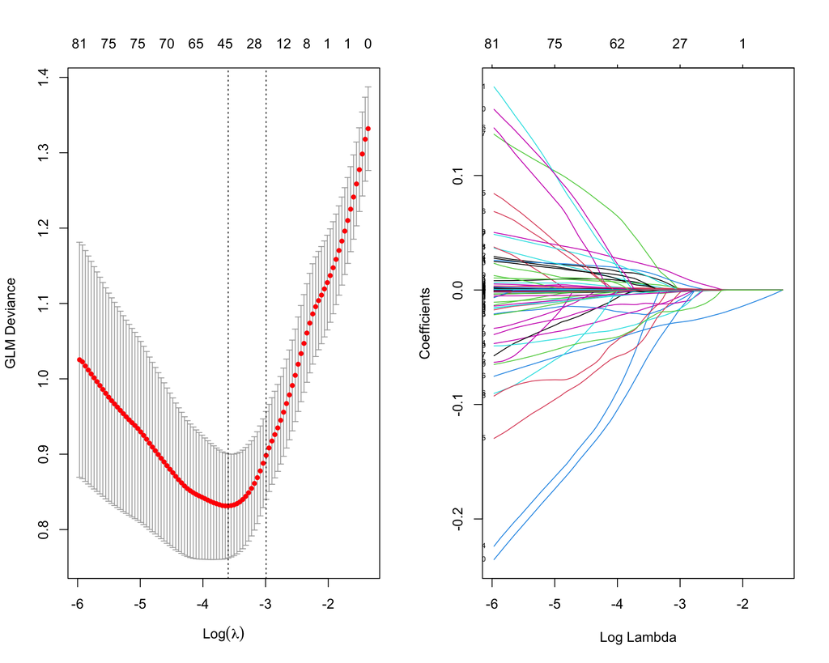

```r
library(glmnet)
par(mfrow=c(1,2))
# run lasso (alpha=1) for linear model (family=binomial)
cvglm=cv.glmnet(as.matrix(X),Y, family=binomial(), alpha=1, standardize=T, nfolds=10)

plot(cvglm)
plot(cvglm$glmnet.fit, xvar="lambda",label=T)
```

```r
minlambda=cvglm$lambda.min
print(minlambda)
```

```
## [1] 0.02741586
```

#### Feature selection

Once we know the optimal $\lambda$, we can display the names of the most informative features selected by LASSO for that optimal $\lambda$.

```r
genes<-colnames(X)[unlist(predict(cvglm, s = "lambda.min", type = "nonzero"))]
betas= data.frame(genes = genes,
                  betas=unlist(coef(cvglm, s="lambda.min")[genes,]))
betas<-betas[order(-abs(betas$betas)), ]
datatable(betas)
```

| genes | betas |
| --- | --- |
| ENSG00000254510.1_RP11-867G23.10 | -0.0662492 |
| ENSG00000227407.1_AC008746.3 | -0.0438836 |
| ENSG00000151023.12_ENKUR | 0.0372598 |
| ENSG00000233012.2_HDAC1P2 | -0.0357041 |
| ENSG00000184368.11_MAP7D2 | -0.0351857 |
| ENSG00000152766.5_ANKRD22 | -0.0284666 |
| ENSG00000267834.1_RP11-167N5.5 | -0.0279633 |
| ENSG00000207697.1_MIR573 | -0.0263295 |
| ENSG00000129007.10_CALML4 | 0.0226915 |
| ENSG00000183808.7_RBM12B | -0.0213125 |
| ENSG00000261529.1_RP13-487P22.1 | -0.0168873 |
| ENSG00000257647.1_RP11-701H24.3 | 0.0163424 |
| ENSG00000271964.1_RP11-415F23.2 | 0.0137938 |
| ENSG00000244306.5_CTD-2314B22.3 | 0.0131199 |
| ENSG00000016602.8_CLCA4 | -0.0118429 |
| ENSG00000230267.2_HERC2P4 | 0.0068612 |
| ENSG00000250240.1_CTD-2154I11.2 | 0.0054912 |
| ENSG00000109943.4_CRTAM | 0.0054177 |
| ENSG00000184949.10_FAM227A | 0.0045770 |
| ENSG00000203836.7_NBPF24 | 0.0037885 |
| ENSG00000161847.9_RAVER1 | -0.0033797 |
| ENSG00000182742.5_HOXB4 | -0.0023954 |
| ENSG00000234336.2_JAZF1-AS1 | -0.0017107 |
| ENSG00000162512.11_SDC3 | 0.0016950 |
| ENSG00000136279.14_DBNL | -0.0014652 |
| ENSG00000261064.1_RP11-1000B6.3 | -0.0014468 |
| ENSG00000128487.12_SPECC1 | -0.0011637 |
| ENSG00000110013.8_SIAE | 0.0010515 |
| ENSG00000144677.10_CTDSPL | -0.0006615 |
| ENSG00000135541.16_AHI1 | -0.0005553 |
| ENSG00000155761.9_SPAG17 | -0.0003065 |
| ENSG00000124749.12_COL21A1 | -0.0002704 |
| ENSG00000198729.4_PPP1R14C | -0.0002651 |
| ENSG00000184304.10_PRKD1 | 0.0002448 |
| ENSG00000135127.7_CCDC64 | 0.0002274 |
| ENSG00000172766.14_NAA16 | -0.0001900 |
| ENSG00000130300.4_PLVAP | 0.0001442 |
| ENSG00000113312.6_TTC1 | 0.0001028 |
| ENSG00000187239.12_FNBP1 | 0.0000818 |
| ENSG00000168566.11_SNRNP48 | 0.0000740 |
| ENSG00000137168.7_PPIL1 | -0.0000672 |
| ENSG00000198954.4_KIAA1279 | -0.0000523 |
| ENSG00000140391.10_TSPAN3 | 0.0000423 |
| ENSG00000180817.6_PPA1 | 0.0000067 |

#### AIC of best model

```r
doAIC(X[,genes], Y)
```

```
## [1] "Best model is:"
##          models    aic isAICmin        rl
## 44 44 variables 40.364      Yes 1.000e+00
```

Compared models

AIC

Minimum AIC

rL

1 variable

218.950

1.662e-39

2 variables

211.870

5.727e-38

3 variables

209.520

1.855e-37

4 variables

201.270

1.147e-35

5 variables

201.630

9.584e-36

6 variables

194.870

2.815e-34

7 variables

196.800

1.072e-34

8 variables

192.630

8.627e-34

9 variables

180.590

3.551e-31

10 variables

178.940

8.102e-31

11 variables

180.530

3.659e-31

12 variables

179.130

7.368e-31

13 variables

177.360

1.785e-30

14 variables

177.300

1.840e-30

15 variables

175.020

5.752e-30

16 variables

175.210

5.231e-30

17 variables

175.870

3.761e-30

18 variables

177.790

1.440e-30

19 variables

177.120

2.013e-30

20 variables

163.180

2.142e-27

21 variables

156.160

7.165e-26

22 variables

158.080

2.743e-26

23 variables

147.340

5.895e-24

24 variables

147.900

4.455e-24

25 variables

146.570

8.663e-24

26 variables

89.176

2.515e-11

27 variables

85.035

1.994e-10

28 variables

86.585

9.188e-11

29 variables

79.412

3.318e-09

30 variables

78.357

5.622e-09

31 variables

78.309

5.759e-09

32 variables

75.074

2.903e-08

33 variables

75.144

2.803e-08

34 variables

44.812

1.082e-01

35 variables

46.808

3.988e-02

36 variables

47.866

2.349e-02

37 variables

47.276

3.156e-02

38 variables

45.886

6.323e-02

39 variables

47.147

3.366e-02

40 variables

46.762

4.080e-02

41 variables

46.380

4.939e-02

42 variables

47.157

3.349e-02

43 variables

47.480

2.850e-02

44 variables

40.364

Yes

1.000e+00

#### Think about:

- How does the LASSO result compare to the results form AIC and univariate analyses?
- Think about the reasons for similarity/dissimilarity

**Some possible answers**

#### Some possible answers

- The features selected by LASSO includes the gene from the univariate approach, but also several others
  - This is often the case in practice
  - Multiple test correction reduces the power of the univariate approach
- The optimal LASSO model is different from those obtained from the various AIC approach (most likely:); moreover, the optimal LASSO model has a lower AIC than those investigated in the AIC approach (most likely)
  - In general, unless we test all models corresponding all possible combinatorial subsets of variables or apply some clever search algorithm (similar to the one LASSO uses), we are unlikely to find the optimal model.
    - Even then, we might get different answers, because the regularization applied in AIC and LASSO are different.

## Session info

**R version 4.0.2 (2020-06-22)**

**Platform:** x86_64-apple-darwin17.0 (64-bit)

**locale:** en_US.UTF-8||en_US.UTF-8||en_US.UTF-8||C||en_US.UTF-8||en_US.UTF-8

**attached base packages:** *stats*, *graphics*, *grDevices*, *utils*, *datasets*, *methods* and *base*

**other attached packages:** *pander(v.0.6.3)*, *DT(v.0.15)*, *glmnet(v.4.0-2)*, *Matrix(v.1.2-18)*, *dplyr(v.1.0.2)*, *kableExtra(v.1.2.1)*, *lmtest(v.0.9-38)*, *zoo(v.1.8-8)*, *ggplot2(v.3.3.2)* and *knitr(v.1.30)*

**loaded via a namespace (and not attached):** *Rcpp(v.1.0.5)*, *lattice(v.0.20-41)*, *zeallot(v.0.1.0)*, *digest(v.0.6.26)*, *foreach(v.1.5.0)*, *mime(v.0.9)*, *R6(v.2.4.1)*, *evaluate(v.0.14)*, *httr(v.1.4.2)*, *xaringan(v.0.17)*, *highr(v.0.8)*, *pillar(v.1.4.6)*, *tfruns(v.1.4)*, *rlang(v.0.4.8)*, *rstudioapi(v.0.11)*, *whisker(v.0.4)*, *reticulate(v.1.18)*, *rmarkdown(v.2.3)*, *keras(v.2.3.0.0)*, *labeling(v.0.3)*, *splines(v.4.0.2)*, *webshot(v.0.5.2)*, *servr(v.0.18)*, *stringr(v.1.4.0)*, *htmlwidgets(v.1.5.1)*, *munsell(v.0.5.0)*, *compiler(v.4.0.2)*, *httpuv(v.1.5.4)*, *xfun(v.0.17)*, *pkgconfig(v.2.0.3)*, *base64enc(v.0.1-3)*, *shape(v.1.4.5)*, *tensorflow(v.2.2.0)*, *htmltools(v.0.5.0)*, *tidyselect(v.1.1.0)*, *tibble(v.3.0.3)*, *bookdown(v.0.20)*, *codetools(v.0.2-16)*, *viridisLite(v.0.3.0)*, *crayon(v.1.3.4)*, *withr(v.2.3.0)*, *later(v.1.1.0.1)*, *grid(v.4.0.2)*, *jsonlite(v.1.7.1)*, *gtable(v.0.3.0)*, *lifecycle(v.0.2.0)*, *magrittr(v.1.5)*, *scales(v.1.1.1)*, *neuralnet(v.1.44.2)*, *stringi(v.1.5.3)*, *farver(v.2.0.3)*, *promises(v.1.1.1)*, *xml2(v.1.3.2)*, *ellipsis(v.0.3.1)*, *vctrs(v.0.3.4)*, *generics(v.0.0.2)*, *iterators(v.1.0.12)*, *tools(v.4.0.2)*, *glue(v.1.4.2)*, *purrr(v.0.3.4)*, *crosstalk(v.1.1.0.1)*, *survival(v.3.2-3)*, *yaml(v.2.2.1)*, *colorspace(v.1.4-1)* and *rvest(v.0.3.6)*